# ai4i_explore

Exercise 10.2 (Working with JupyterLab)

JupyterLab is a web-based interactive development environment (IDE) for Jupyter Notebooks. It provides a flexible interface for interactive data exploration and reporting.

Launch JupyterLab from your uv environment by adding it to your environment first or alternatively, using VS Code, you can also use the Jupyter extension instead. Create a new notebook called ai4i_explore.ipynb. Load the AI4I dataset into a pandas DataFrame using a code cell. Keep only the columns UDI (unique identifier which can be used as axis for plotting), Torque, Rotational speed and Air temperature. Display the first 10 rows and print basic statistics. Create a line plot of Torque over UDI using matplotlib. Experiment with different cell types: code, markdown, and raw cells. Export the notebook as HTML and PDF. After this exercise you should be able to:

Create and organize notebooks in JupyterLab. Differentiate between code, markdown, and raw cells. Export notebooks to other formats (HTML, PDF). Structure a notebook with self-contained, readable code cells.

```python
import numpy as np
import matplotlib.pyplot as plt
import pandas as pd

# URL zum AI4I 2020 Predictive Maintenance Dataset.
# Der Datensatz enthält simulierte Sensordaten einer industriellen Maschine.
url = "https://archive.ics.uci.edu/static/public/601/ai4i+2020+predictive+maintenance+dataset.zip"

# Lädt die CSV-Datei aus dem ZIP-Archiv in einen Pandas DataFrame.
# Ein DataFrame ist eine tabellarische Datenstruktur mit Zeilen und Spalten.
df = pd.read_csv(url)

# Wählt die vier für diese Aufgabe benötigten Spalten aus.
df = df[["UDI", "Torque [Nm]", "Rotational speed [rpm]", "Air temperature [K]"]]

print("Erste 10 Zeilen:")

# Zeigt die ersten zehn Zeilen des DataFrames an.
print(df.head(10))

# Berechnet grundlegende statistische Kennwerte der numerischen Spalten.
# Dazu gehören Anzahl, Mittelwert, Standardabweichung,
# Minimum, Maximum und die Quartile (25 %, 50 %, 75 %).
print("\nStatistische Kennwerte:")
print(df.describe())
```

```
Erste 10 Zeilen:
   UDI  Torque [Nm]  Rotational speed [rpm]  Air temperature [K]
0    1         42.8                    1551                298.1
1    2         46.3                    1408                298.2
2    3         49.4                    1498                298.1
3    4         39.5                    1433                298.2
4    5         40.0                    1408                298.2
5    6         41.9                    1425                298.1
6    7         42.4                    1558                298.1
7    8         40.2                    1527                298.1
8    9         28.6                    1667                298.3
9   10         28.0                    1741                298.5

Statistische Kennwerte:
               UDI   Torque [Nm]  Rotational speed [rpm]  Air temperature [K]
count  10000.00000  10000.000000            10000.000000         10000.000000
mean    5000.50000     39.986910             1538.776100           300.004930
std     2886.89568      9.968934              179.284096             2.000259
min        1.00000      3.800000             1168.000000           295.300000
25%     2500.75000     33.200000             1423.000000           298.300000
50%     5000.50000     40.100000             1503.000000           300.100000
75%     7500.25000     46.800000             1612.000000           301.500000
max    10000.00000     76.600000             2886.000000           304.500000
```

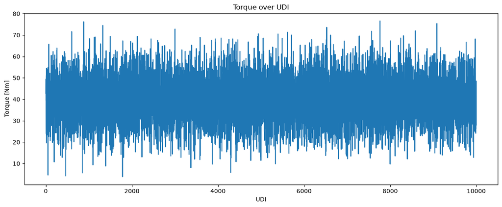

```python
import matplotlib.pyplot as plt     # Importiert Matplotlib

# Erstellt eine neue Abbildung mit einer Breite von 12 und Höhe von 5 Zoll.
plt.figure(figsize=(12, 5))

# Zeichnet das Drehmoment über der eindeutigen Datensatznummer UDI.
# Jeder Datenpunkt wird über eine Linie mit dem nächsten verbunden.
plt.plot(df["UDI"], df["Torque [Nm]"])

# Fügt einen Titel und die Achsenbeschriftungen hinzu.
plt.title("Torque over UDI")
plt.xlabel("UDI")
plt.ylabel("Torque [Nm]")

# Passt die Abstände automatisch an, damit Beschriftungen nicht abgeschnitten werden.
plt.tight_layout()

# Zeigt das fertige Diagramm an.
plt.show()
```

```python
#Code Zelle:
#Enthält ausführbaren Python-Code
```

Markdown Zelle: Dient der Dokumentation

Export als html mit:

uv run jupyter nbconvert --to html "Tasks/10 Self study - Session 1/ai4i_explore.ipynb"